# Exercice_R

Yunfan CAI, Dylan SI, Victor Chau, Pierre Bonneau

2022-10-28

## EXERCICE 1

Claude, qui travaille dans une banque, a appris votre nouvelle expertise dans la modélisation de systèmes par réseaux bayésiens, et demande votre aide pour construire un modèle prédictif de la solvabilité de ses client(e)s. Claude vous mentionne que les variables suivantes sont accessibles pour la construction du modèle prédictif pour chaque client(e): • Revenus (Élevé, Moyen, Faibles) • Actifs (Élevé, Moyen, Faibles) • Ratio dettes vs revenus (Élevé, Moyen, Faible) • Historique de paiement (Bon,mauvais) • Âge (moins de 25 ans, entre 25 et 50, entre 50 et 65, 65 et plus) Ultimement, Claude croit que la solvabilité de client(e)s dépend de: • leur fiabilité (Fiable, non fiable) • leur revenus futurs (Élevés, Moyens, Faibles) • leur ratio dettes vs revenus (Élevé, Moyen, Faible). L’expérience de Claude l’amène à croire que :

1. Un(e) client(e) avec un **bon historique de paiement** a tendance à être plus **fiable**;
2. Plus un(e) client(e) est **âgé(e)**, plus il/elle a de chance d’être **fiable**;
3. Les clients plus **âgés** ont tendance à avoir un fiable **ratio dettes vs revenus**;
4. La probabilité d’avoir un **bon historique de paiement** augmente au fur et à mesure que le **ratio de dette vs revenus diminue**;
5. Plus les **revenus** d’une personne sont élevés, plus cette personne a de chance d’avoir des **actifs** élevés;
6. Plus une personne a **d’actifs**, plus cette personne a de chance d’avoir un **revenu** élevé dans le futur;
7. Une personne **fiable** a tendance à être plus **solvable** qu’une personne non fiable;
8. Les personnes qui ont des **revenus prometteurs** ont plus de chance d’être **solvables** que celles dont la perspective des revenus à venir est mauvaise.

**1 - Représentation graphique du réseau**

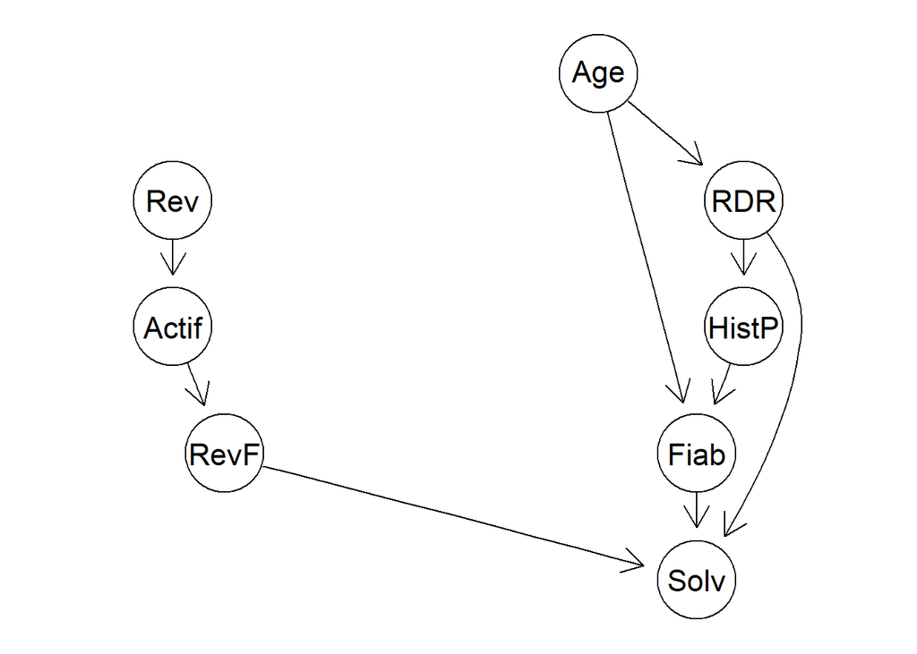

```r
dag_bank = dag(~Rev, ~Age, ~RDR|Age, ~HistP|RDR,
               ~Fiab|HistP:Age,
               ~Actif|Rev, ~RevF|Actif,
               ~Solv|RDR:Fiab:RevF)
plot(dag_bank)
```

**2 - Élicitation des tables de probabilités conditionnelles**

```r
val = c("0","1") ## valeurs possibles pour chacune des variables
val0 = c("non Élevé","Élevé")
val1 = c("Mauvais","Bon")
val2 = c("non Fiable","Fiable")
val3 = c("non Agé","Agé")


cp_Rev <- cptable(~Rev,values=c(66,33),levels=val0)
cp_Age <- cptable(~Age,values=c(50,50),levels=val3)
cp_RDR <- cptable(~RDR|Age,values=c(60,40,40,60),levels=val0)
cp_HistP <- cptable(~HistP|RDR, values = c(45,55,55,45),levels=val1)
cp_Actif <- cptable(~Actif|Rev,values = c(75,25,25,75),levels=val0)
cp_RevF <- cptable(~RevF|Actif,values = c(75,25,25,75),levels=val0)
cp_Fiab <- cptable(~Fiab|HistP+Age,values = c(95,5,90,10,10,90,5,95),levels=val2)
cp_Solv <- cptable(~Solv|RDR+Fiab+RevF,values = c(95,5,90,10,85,15,80,20,20,80,15,85,10,90,5,95),levels=val2)

net_list = compileCPT(list(cp_Rev,cp_Age,cp_RDR,cp_HistP,cp_Actif,cp_RevF,cp_Fiab,cp_Solv))
grain_bank = grain(net_list)
```

1. P(F = fiable | H = bon) > P(F = fiable | H = mauvais).

```r
print(querygrain(grain_bank, nodes=c("HistP","Fiab"), type="conditional"))
```

```
##          Fiab
## HistP     non Fiable Fiable
##   Mauvais     0.5165 0.4835
##   Bon         0.4835 0.5165
```

2. P(Age = Agé | Fiab = fiable) > P(Age = Agé | F = pas fiable).

```r
print(querygrain(grain_bank, nodes=c("Age","Fiab"), type="conditional"))
```

```
##          Fiab
## Age       non Fiable Fiable
##   non Agé     0.9245 0.0755
##   Agé         0.0755 0.9245
```

3. P(Age = Agé | RDR = élevé) > P(Age = Agé | RDR = non élevé).

```r
print(querygrain(grain_bank, nodes=c("Age","RDR"), type="conditional"))
```

```
##          RDR
## Age       non Élevé Élevé
##   non Agé       0.6   0.4
##   Agé           0.4   0.6
```

4. P(RDR = élevé | HistP = mauvais) > P(RDR = élevé | Histp = bon).

```r
print(querygrain(grain_bank, nodes=c("RDR","HistP"), type="conditional"))
```

```
##            HistP
## RDR         Mauvais  Bon
##   non Élevé    0.45 0.55
##   Élevé        0.55 0.45
```

5. P(Rev = élevé | Actif = élevé) > P(RDR = élevé | Histp = non élevé).

```r
print(querygrain(grain_bank, nodes=c("Rev","Actif"), type="conditional"))
```

```
##            Actif
## Rev         non Élevé Élevé
##   non Élevé 0.8571429   0.4
##   Élevé     0.1428571   0.6
```

6. P(Actif = élevé | RevF = élevé) > P(Actif = élevé | RevF = non élevé).

```r
print(querygrain(grain_bank, nodes=c("Actif","RevF"), type="conditional"))
```

```
##            RevF
## Actif       non Élevé     Élevé
##   non Élevé 0.8076923 0.3181818
##   Élevé     0.1923077 0.6818182
```

7. P(Fiab = fiable | Solv = fiable) > P(Fiab = fiable | Solv = non fiable).

```r
print(querygrain(grain_bank, nodes=c("Fiab","Solv"), type="conditional"))
```

```
##             Solv
## Fiab         non Fiable    Fiable
##   non Fiable  0.5509412 0.4422667
##   Fiable      0.4490588 0.5577333
```

8. P(RevF = élevé | Solv = fiable) > P(RevF = élevé | Solv = non fiable).

```r
print(querygrain(grain_bank, nodes=c("RevF","Solv"), type="conditional"))
```

```
##            Solv
## RevF        non Fiable    Fiable
##   non Élevé  0.8921569 0.1444444
##   Élevé      0.1078431 0.8555556
```

## EXERCICE 2

```r
data(marks)

notes_reussite = (marks >=45)*1
#notes_reussite[notes_reussite==1] = "R"
#notes_reussite[notes_reussite==0] = "E"


f1 <- function(x,p1){
  a=0
  if((x==0) || (x==1) )
  {
    a = p1^x * (1-p1)^(1-x)
  }
  return(a)
}

f2 <- function(x,y,p2,p3){
  a=0
  if( ((x==0) || (x==1)) && ((y==0) || (y==1)) )
  {
    a = (p2^x * (1-p2)^(1-x))^y * (p3^x * (1-p3)^(1-x))^(1-y)
  }
  return(a)
}

f3 <- function(x,y,z,p4,p5,p6,p7){
  a=0
  if(((x==0) || (x==1)) && ((y==0) || (y==1)) && ((z==0) || (z==1)) )
  {
    a = ((p4^x * (1-p4)^(1-x))^y * (p5^x * (1-p5)^(1-x))^(1-y))^(z) *
      ((p6^x * (1-p6)^(1-x))^y * (p7^x * (1-p7)^(1-x))^(1-y))^(1-z)
  }
  return(a)
}

f4 <- function(x,y,p8,p9){
  a=0
  if( ((x==0) || (x==1)) && ((y==0) || (y==1)) )
  {
    a = (p8^x * (1-p8)^(1-x))^y * (p9^x * (1-p9)^(1-x))^(1-y)
  }
  return(a)
}

f5 <- function(x,y,z,p10,p11,p12,p13){
  a=0
  if(((x==0) || (x==1)) && ((y==0) || (y==1)) && ((z==0) || (z==1)) )
  {
    a = ((p10^x * (1-p10)^(1-x))^y * (p11^x * (1-p11)^(1-x))^(1-y))^(z) *
      ((p12^x * (1-p12)^(1-x))^y * (p13^x * (1-p13)^(1-x))^(1-y))^(1-z)
  }
  return(a)
}


L <- function(x1,x2,x3,x4,x5,p1,p2,p3,p4,p5,p6,p7,p8,p9,p10,p11,p12,p13){
  return(f1(x5,p1)*f2(x4,x5,p2,p3)*f3(x3,x4,x5,p4,p5,p6,p7)*
           f4(x2,x3,p8,p9)*f5(x1,x2,x3,p10,p11,p12,p13))
}
# = L(x1,x2,x3,x4,x5,p1,p2,p3,p4,p5,p6,p7,p8,p9,p10,p11,p12,p13)




Nstat_1=0
NAnl_1_Stat_1=0
NAnl_1_Stat_0=0
NAlg_1_Anl_1_Stat_1=0
NAlg_1_Anl_0_Stat_1=0
NAlg_1_Anl_1_Stat_0=0
NAlg_1_Anl_0_Stat_0=0
NAlg_1=0
NVect_1_NAlg_1=0
NVect_1_NAlg_0=0
NMech_1_Vect_1_Alg_1=0
NMech_1_Vect_0_Alg_1=0
NMech_1_Vect_1_Alg_0=0
NMech_1_Vect_0_Alg_0=0
for(i in 1:88){
  if(notes_reussite[i,5]==1){
    Nstat_1=Nstat_1+1
  }
  if((notes_reussite[i,4]==1)&&(notes_reussite[i,5]==1)){
    NAnl_1_Stat_1=NAnl_1_Stat_1+1
  }
  if((notes_reussite[i,4]==1)&&(notes_reussite[i,5]==0)){
    NAnl_1_Stat_0=NAnl_1_Stat_0+1
  }
  if((notes_reussite[i,3]==1)&&(notes_reussite[i,4]==1)&&(notes_reussite[i,5]==1)){
    NAlg_1_Anl_1_Stat_1=NAlg_1_Anl_1_Stat_1+1
  }
  if((notes_reussite[i,3]==1)&&(notes_reussite[i,4]==0)&&(notes_reussite[i,5]==1)){
    NAlg_1_Anl_0_Stat_1=NAlg_1_Anl_0_Stat_1+1
  }
  if((notes_reussite[i,3]==1)&&(notes_reussite[i,4]==1)&&(notes_reussite[i,5]==0)){
    NAlg_1_Anl_1_Stat_0=NAlg_1_Anl_1_Stat_0+1
  }
  if((notes_reussite[i,3]==1)&&(notes_reussite[i,4]==0)&&(notes_reussite[i,5]==0)){
    NAlg_1_Anl_0_Stat_0=NAlg_1_Anl_0_Stat_0+1
  }
  if(notes_reussite[i,3]==1){
    NAlg_1=NAlg_1+1
  }
  if((notes_reussite[i,2]==1)&&(notes_reussite[i,3]==1)){
    NVect_1_NAlg_1=NVect_1_NAlg_1+1
  }
  if((notes_reussite[i,2]==1)&&(notes_reussite[i,3]==0)){
    NVect_1_NAlg_0=NVect_1_NAlg_0+1
  }
  if((notes_reussite[i,1]==1)&&(notes_reussite[i,2]==1)&&(notes_reussite[i,3]==1)){
    NMech_1_Vect_1_Alg_1=NMech_1_Vect_1_Alg_1+1
  }
  if((notes_reussite[i,1]==1)&&(notes_reussite[i,2]==0)&&(notes_reussite[i,3]==1)){
    NMech_1_Vect_0_Alg_1=NMech_1_Vect_0_Alg_1+1
  }
  if((notes_reussite[i,1]==1)&&(notes_reussite[i,2]==1)&&(notes_reussite[i,3]==0)){
    NMech_1_Vect_1_Alg_0=NMech_1_Vect_1_Alg_0+1
  }
  if((notes_reussite[i,1]==1)&&(notes_reussite[i,2]==0)&&(notes_reussite[i,3]==0)){
    NMech_1_Vect_0_Alg_0=NMech_1_Vect_0_Alg_0+1
  }



}
p1=Nstat_1/88
p2=NAnl_1_Stat_1/Nstat_1
p3=NAnl_1_Stat_0/(88-Nstat_1)
p4=NAlg_1_Anl_1_Stat_1/(p2*p1*88)
p5=NAlg_1_Anl_0_Stat_1/((1-p2)*p1*88)
p6=NAlg_1_Anl_1_Stat_0/(p3*(1-p1)*88)
p7=NAlg_1_Anl_0_Stat_0/(p3*(1-p1)*88)
p8=NVect_1_NAlg_1/NAlg_1
p9=NVect_1_NAlg_0/(88-NAlg_1)
p10=NMech_1_Vect_1_Alg_1/(p8*(NAlg_1/88)*88)
p11=NMech_1_Vect_0_Alg_1/((1-p8)*(NAlg_1/88)*88)
p12=NMech_1_Vect_1_Alg_0/(p8*(1-(NAlg_1/88))*88)
p13=NMech_1_Vect_0_Alg_0/(p8*(1-(NAlg_1/88))*88)

#p1=P(Stat=1)
print(p1)
```

```
## [1] 0.3863636
```

```r
#p2=P(Anl=1|Stat=1)
print(p2)
```

```
## [1] 0.8529412
```

```r
#p3=P(Anl=1|Stat=0)
print(p3)
```

```
## [1] 0.5555556
```

```r
#p4=P(Alg=1|Anl=1,Stat=1)
print(p4)
```

```
## [1] 0.9655172
```

```r
#p5=P(Alg=1|Anl=0,Stat=1)
print(p5)
```

```
## [1] 0.8
```

```r
#p6=P(Alg=1|Anl=1,Stat=0)
print(p6)
```

```
## [1] 0.8333333
```

```r
#p7=P(Alg=1|Anl=0,Stat=0)
print(p7)
```

```
## [1] 0.3333333
```

```r
#p2=P(Vect=1|Alg=1)
print(p8)
```

```
## [1] 0.7761194
```

```r
#p3=P(Vect=1|Alg=0)
print(p9)
```

```
## [1] 0.2857143
```

```r
#p4=P(Mech=1|Vect=1,Alg=1)
print(p10)
```

```
## [1] 0.5576923
```

```r
#p5=P(Mech=1|Vect=0,Alg=1)
print(p11)
```

```
## [1] 0.3333333
```

```r
#p6=P(Mech=1|Vect=1,Alg=0)
print(p12)
```

```
## [1] 0.1227106
```

```r
#p7=P(Mech=1|Vect=0,Alg=0)
print(p13)
```

```
## [1] 0.1227106
```

```r
petoile <- function(p1,p2,p3,p4,p5,p6,p7,p8,p9,p10,p11,p12,p13) {
  P=1
  for(i in 1:88 ){
    Xi = notes_reussite[i,]
    P=P*L(Xi[1],Xi[2],Xi[3],Xi[4],Xi[5],p1,p2,p3,p4,p5,p6,p7,p8,p9,p10,p11,p12,p13)
  }
  return (P)
}


petoile2 <- function(Plist) {
  P=1
  for(i in 1:88 ){
    Xi = notes_reussite[i,]
    #P=P*L(Xi[1],Xi[2],Xi[3],Xi[4],Xi[5],Plist[1],Plist[2],Plist[3],Plist[4],Plist[5],
          #Plist[6],Plist[7],Plist[8],Plist[9],Plist[10],Plist[11],Plist[12],Plist[13])
    P=P+log(L(Xi[1],Xi[2],Xi[3],Xi[4],Xi[5],Plist[1],Plist[2],Plist[3],Plist[4],Plist[5],
          Plist[6],Plist[7],Plist[8],Plist[9],Plist[10],Plist[11],Plist[12],Plist[13]))
  }
  return (-P) # on fait -P pour avoir argmax au lieux de argmin
}



notes_reussite[1,]
```

```
## MECH VECT  ALG  ANL STAT
##    1    1    1    1    1
```

```r
#test = petoile(0.1,0.2,0.3,0.4,0.5,0.6,0.7,0.1,0.2,0.3,0.4,0.5,0.6)
#test

#x0 <- c(p1,p2,p3,p4,p5,p6,p7,p8,p9,p10,p11,p12,p13)
x0 <- c(0.5,0.5,0.5,0.5,0.5,0.5,0.5,0.5,0.5,0.5,0.5,0.5,0.5)

solution <- optim(x0, petoile2)
print(solution$counts)
```

```
## function gradient
##      502       NA
```

```r
#la solution est déjà minimum
print(solution$par)
```

```
##  [1] 0.38589839 0.81888775 0.55986154 0.96479956 0.52862065 0.82099768
##  [7] 0.43109717 0.77892814 0.32375379 0.54137566 0.26393970 0.38264238
## [13] 0.08296025
```

```r
print(solution$value)
```

```
## [1] 250.305
```

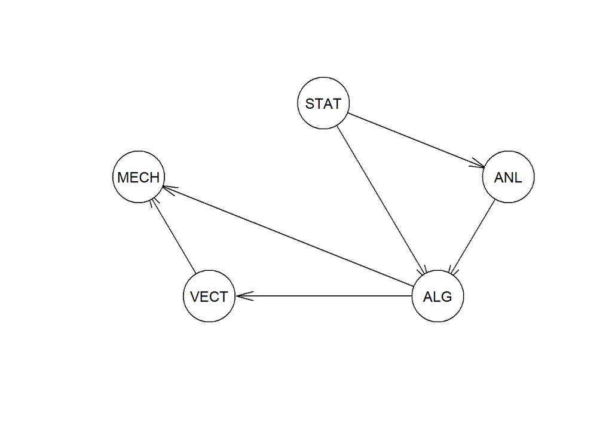

```r
#minf <- optimize(v,c(c(0,1),c(0,1),c(0,1),c(0,1),c(0,1),c(0,1),c(0,1),c(0,1),c(0,1),c(0,1),c(0,1),c(0,1),c(0,1),maximum=FALSE))

#minf = optimize(petoile2,c(c(0,1),c(0,1),c(0,1),c(0,1),c(0,1),c(0,1),c(0,1),c(0,1),c(0,1),c(0,1),c(0,1),c(0,1),c(0,1),maximum=FALSE))




#notes_reussite[1,]

#test = petoile(0.1,0.2,0.3,0.4,0.5,0.6,0.7,0.1,0.2,0.3,0.4,0.5,0.6)
#test

#x0 <- c(0,0,0,0,0,0,0,0,0,0,0,0,0.3)

#solution <- optim(x0, petoile2)


#print(solution$counts)
#print(solution$par)
#print(solution$value)


#minf <- optimize(petoile2, c(c(0,1), c(0,1),c(0,1),c(0,1),c(0,1),c(0,1),c(0,1),c(0,1),c(0,1),c(0,1),c(0,1),c(0,1),c(0,1))    )

#print(minf$minimum)
#print(minf$objective)



dag_notes = empty.graph(names(marks))
arcs(dag_notes) = matrix(
c("VECT", "MECH",
"ALG", "MECH",
"ALG", "VECT",
"ANL", "ALG",
"STAT", "ALG",
"STAT", "ANL"),
ncol = 2, byrow = TRUE, dimnames = list(c(), c("from", "to")))
plot(dag_notes)
```

```r
bn.fit(dag_notes, data = as.data.frame(notes_reussite))
```

```
##
##   Bayesian network parameters
##
##   Parameters of node MECH (Gaussian distribution)
##
## Conditional density: MECH | VECT + ALG
## Coefficients:
## (Intercept)         VECT          ALG
##   0.1282463    0.2178046    0.2101740
## Standard deviation of the residuals: 0.4756269
##
##   Parameters of node VECT (Gaussian distribution)
##
## Conditional density: VECT | ALG
## Coefficients:
## (Intercept)          ALG
##   0.2857143    0.4904051
## Standard deviation of the residuals: 0.4303528
##
##   Parameters of node ALG (Gaussian distribution)
##
## Conditional density: ALG | ANL + STAT
## Coefficients:
## (Intercept)          ANL         STAT
##   0.4504797    0.3558032    0.1872176
## Standard deviation of the residuals: 0.3752541
##
##   Parameters of node ANL (Gaussian distribution)
##
## Conditional density: ANL | STAT
## Coefficients:
## (Intercept)         STAT
##   0.5555556    0.2973856
## Standard deviation of the residuals: 0.4523587
##
##   Parameters of node STAT (Gaussian distribution)
##
## Conditional density: STAT
## Coefficients:
## (Intercept)
##   0.3863636
## Standard deviation of the residuals: 0.4897059
```